# Explore covariates

Aidan Brushett

2025-04-08

# Before you begin

This script is number 3 of 5 in a series of scripts used to replicate the analyses presented in the paper: “Life on the edge: Industrial footprint and edge effects variably affect the distribution of a boreal small mammal”

This script was used to conduct the exploratory analysis for all potential landscape covariates in our dataset prior to modelling. **The raw spatial data used to develop landcover metrics is not available on GitHub but can be shared by the authors upon request.**

When running these scripts, please ensure that you have downloaded the complete GitHub repository. This will ensure you have all the files, data, and proper folder structure you will need to run this code and associated analyses.

Also make sure you open RStudio through the R project (OSM_red_squirrel_distribution.Rproj). This will automatically set your working directory to the correct place (wherever you saved the repository) and ensure you don’t have to change the file paths for some of the data. This analysis was initially run in R v4.3.0. If you have any questions or concerns, please contact one of the authors:

Aidan Brushett M.Sc. Student University of Victoria  
School of Environmental Studies  
Email: aidanbrushett@uvic.ca

Emerald Arthurs M.Sc. Student University of Victoria  
School of Environmental Studies

# 0. Setup

```r
rm(list=ls()) # start fresh :)

library(tidyverse)
library(ggplot2)
library(writexl)

# These are functions that can sometimes get masked by other packages. Shouldn't be an issue and could be removed.
select <- dplyr::select
filter <- dplyr::filter
mutate <- dplyr::mutate
summarize <- dplyr::summarize
# Cheeky function that means "not in"
`%nin%` = Negate(`%in%`)
```

# 1. Import data

```r
covs <- read_csv("./data/processed/OSM_all_covariates_HFI_SBFI_final.csv")
names(covs)
```

```
##  [1] "array"                  "site"                   "array_year"
##  [4] "lat"                    "long"                   "easting_12n"
##  [7] "northing_12n"           "buffer_dist"            "cfi_site"
## [10] "cfi_site_with_harvest"  "cfi_site_with_vegedges" "harvest_0_15"
## [13] "harvest_gt_15"          "harvest_total"          "osm_industrial"
## [16] "pipe_trans"             "railways"               "roads"
## [19] "seismic"                "seismic_lines"          "seismic_lines_3D"
## [22] "trails"                 "veg_edges"              "wells_active"
## [25] "wells_inactive"         "wells_total"            "pct_betu_pap"
## [28] "fire_0_15"              "fire_gt_15"             "pct_lari_lar"
## [31] "lc_broadleaf"           "lc_coniferous"          "lc_herbs"
## [34] "lc_mixedwood"           "lc_shrubs"              "lc_water"
## [37] "lc_wetland"             "lc_wetland_treed"       "pct_pice_gla"
## [40] "pct_pice_mar"           "pct_pinu_ban"           "pct_popu_tre"
## [43] "nonanthro_cai_mn"       "nonanthro_ed"           "nonanthro_tca"
## [46] "landscape_cai_mn"       "landscape_ed"           "landscape_tca"
## [49] "landscape_contag"       "landscape_mesh"         "landscape_np"
## [52] "landscape_shei"         "landscape_siei"
```

Identify the covariates of interest.

```r
covs_to_explore <- covs %>%

  # To keep the number of plots reasonable we'll remove some things we're 99% sure we don't want to model
  select(
    -contains("gt"),
    -railways,
    -seismic_lines,
    -seismic_lines_3D,
    -trails,
    -veg_edges,
    -lc_water,
    -pct_betu_pap
         ) %>%

  relocate((1:8), sort(names(.)))
```

# 2. Data distribution

Histograms at 500 meters:

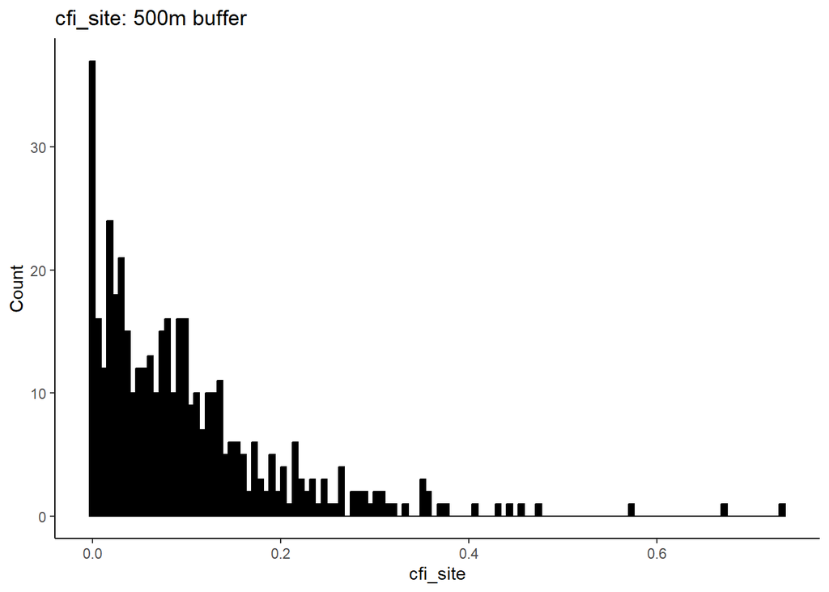

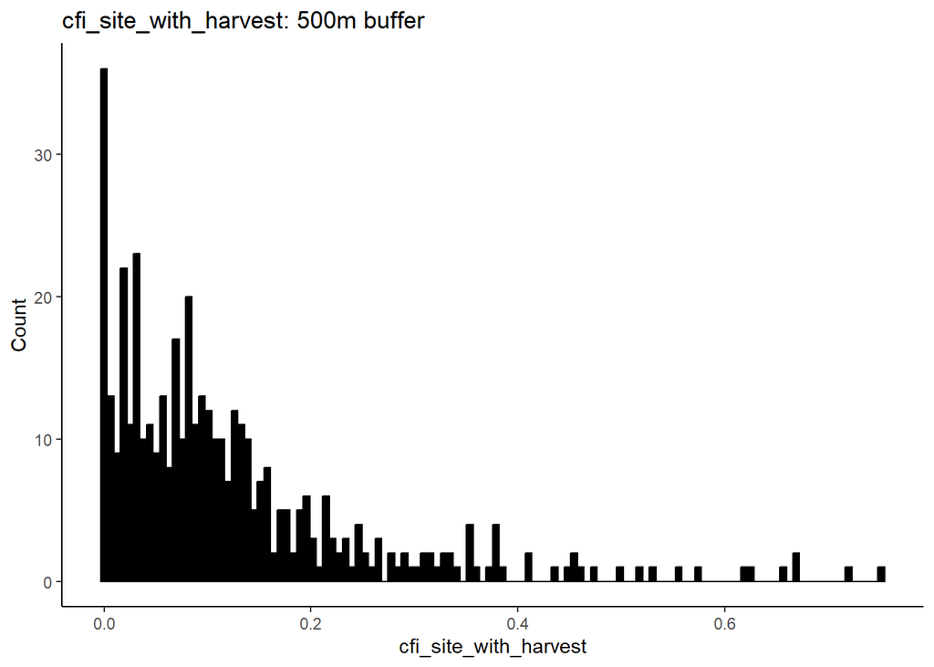

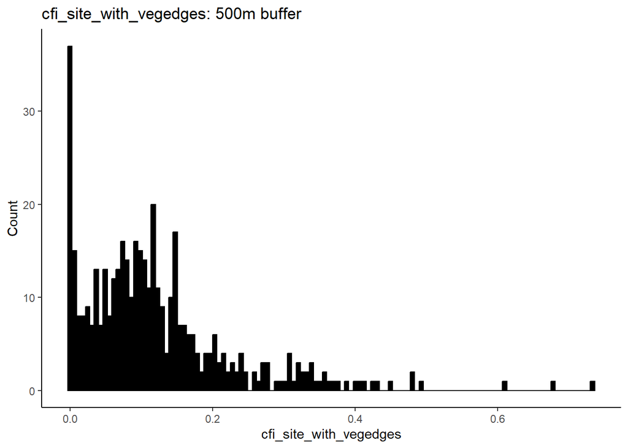

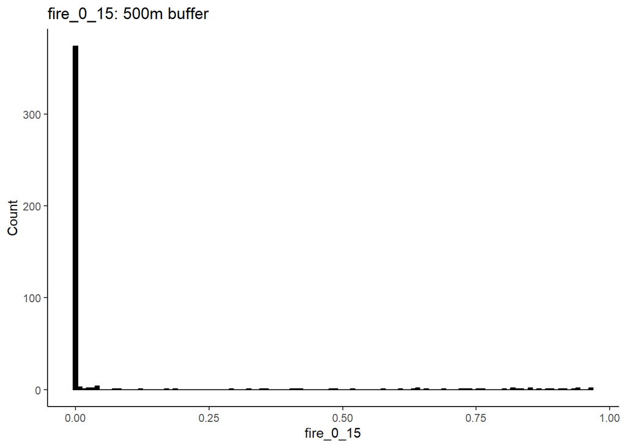

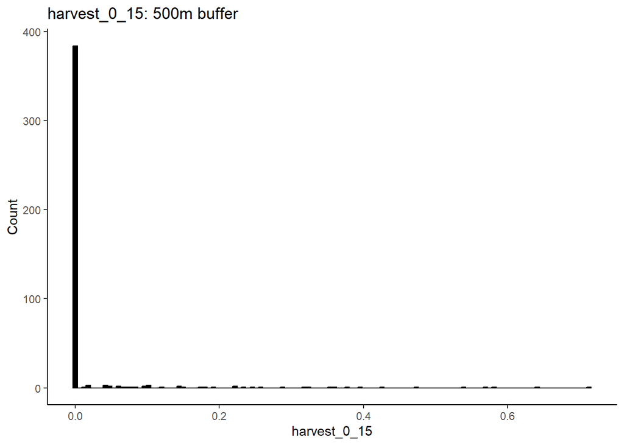

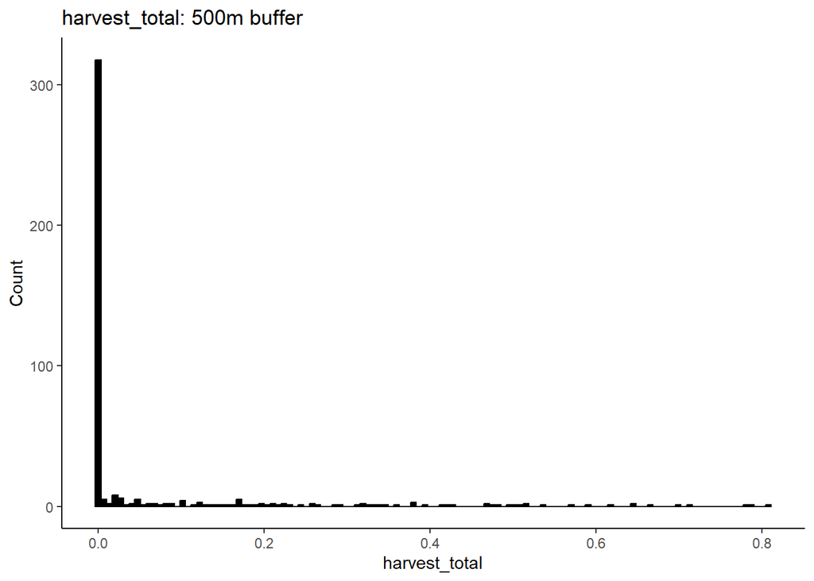

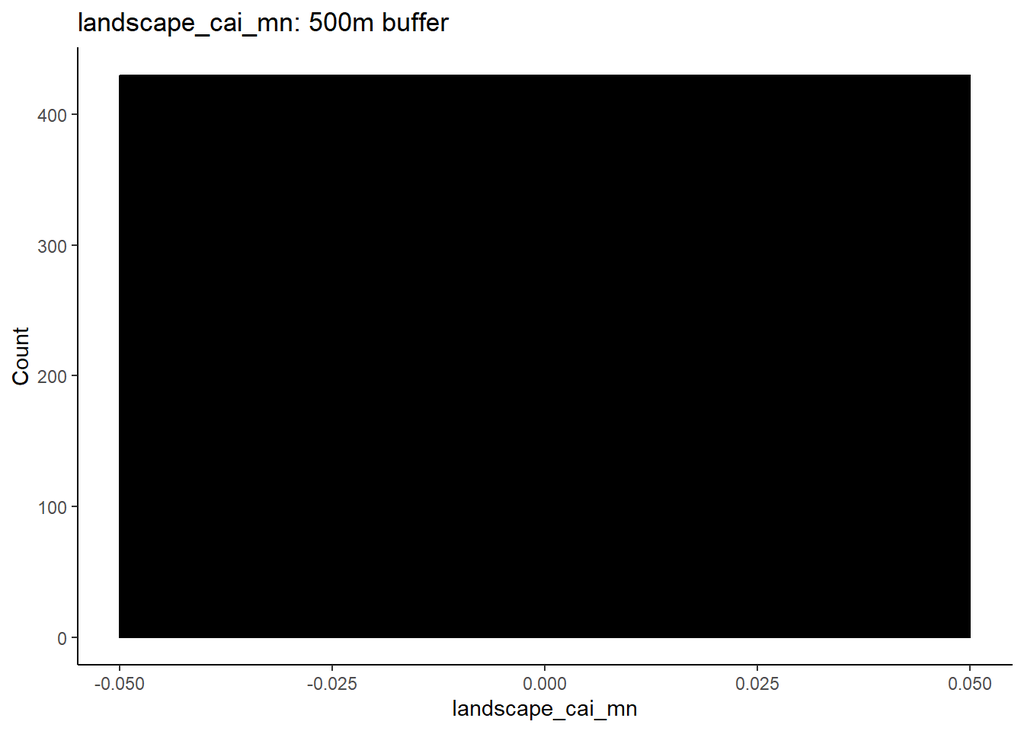

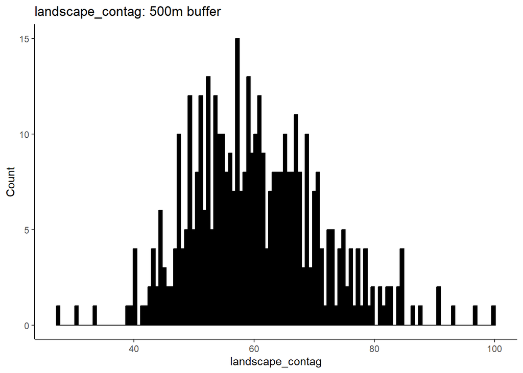

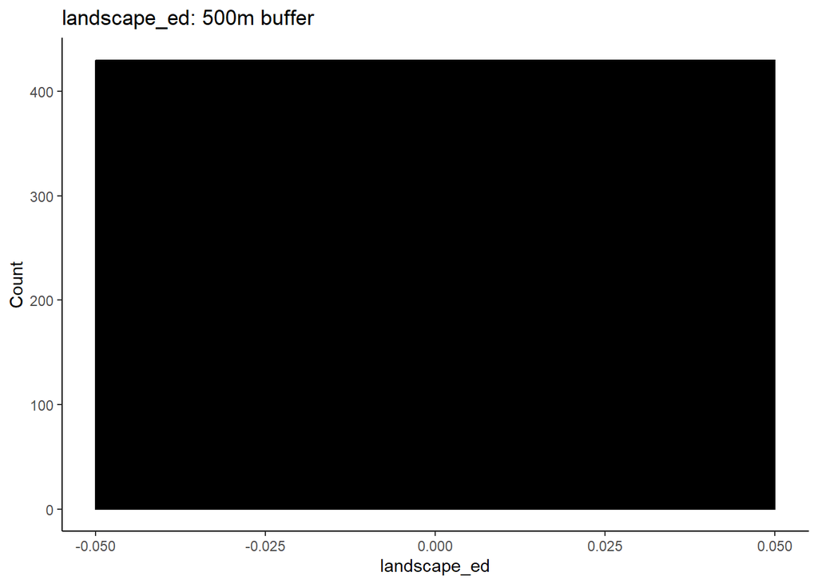

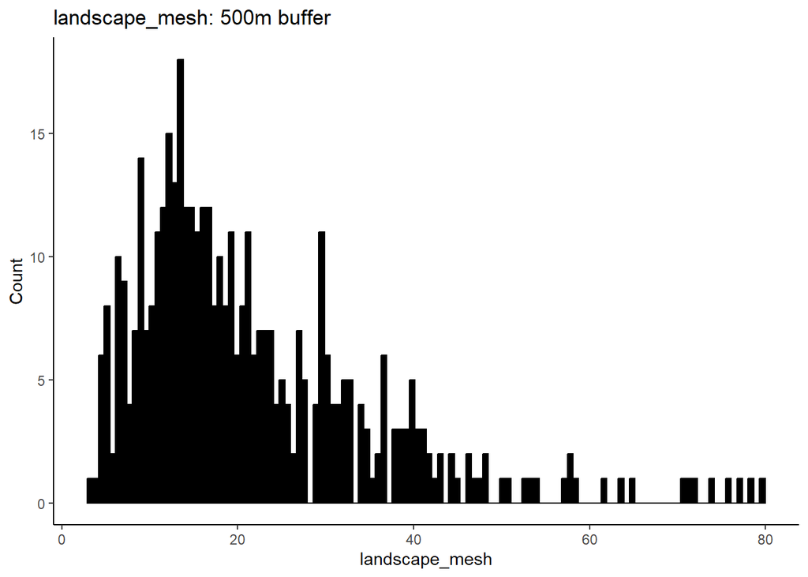

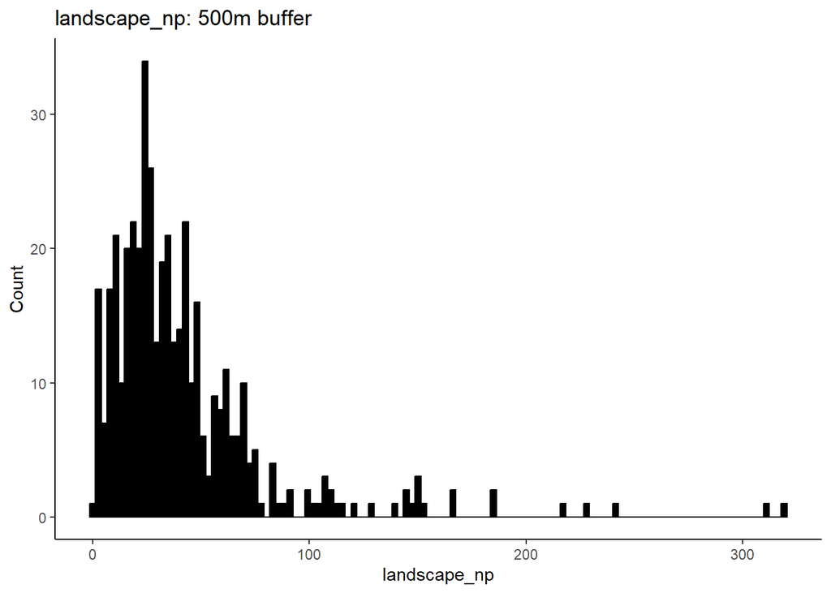

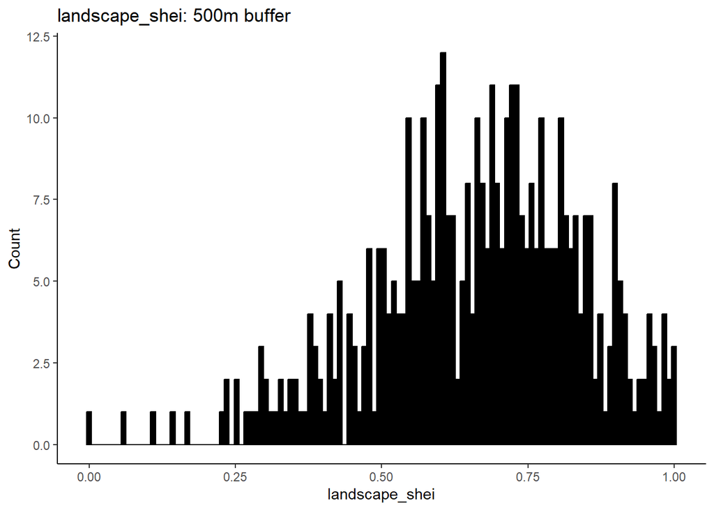

[24 more figures not shown]

```r
covs_to_explore %>%

  filter(buffer_dist == 500) %>%

  # Remove the response columns
  select(-(1:8)) %>%

  # use imap which will retain both the data (x) and the variable names (y)
  imap(~ ggplot(mapping = aes(x = .x)) +
         geom_histogram(bins = 120, fill = "black", color = "black") +
         labs(title = paste0(.y, ": 500m buffer"), x = .y, y = "Count") +
         theme_classic())
```

Box and whiskers at 500 meters:

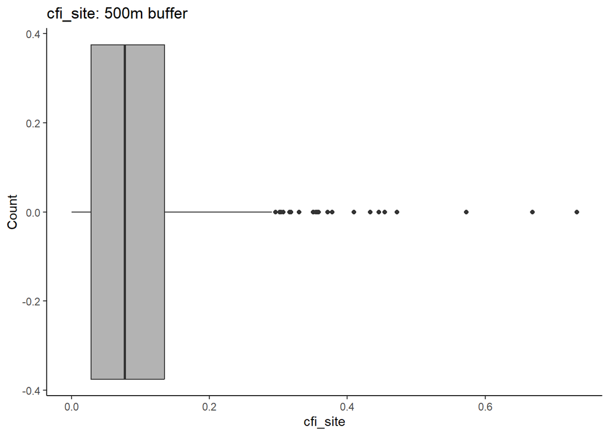

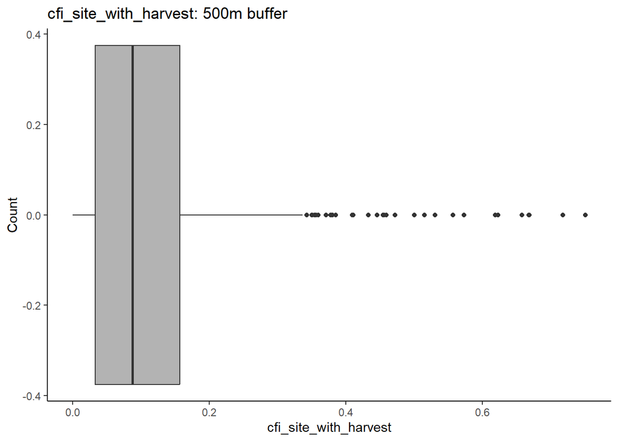

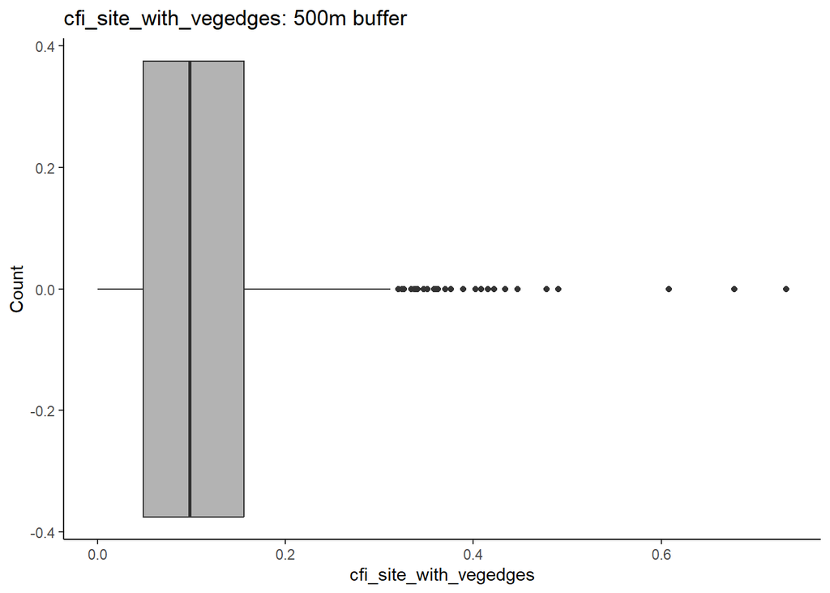

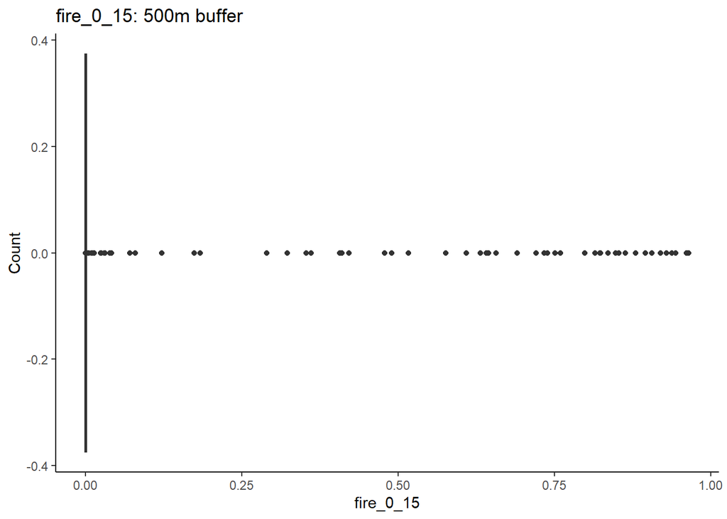

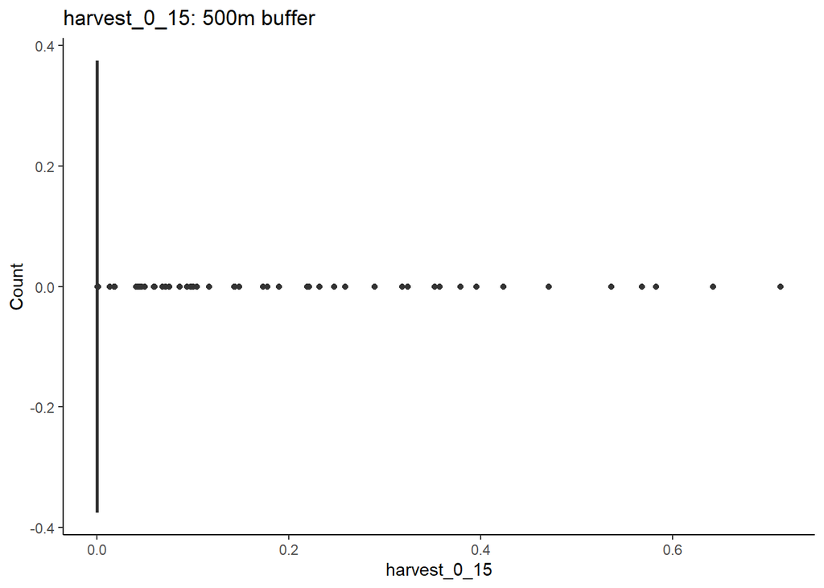

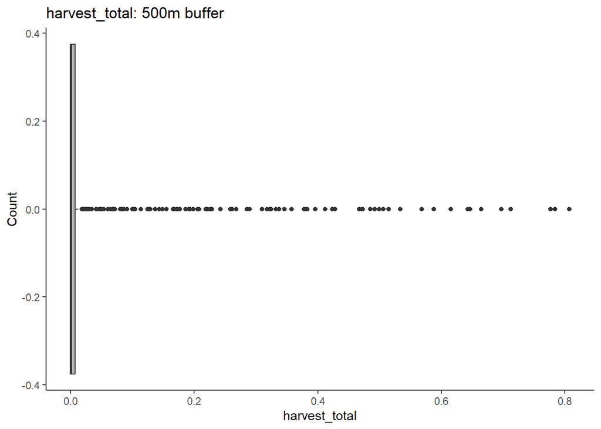

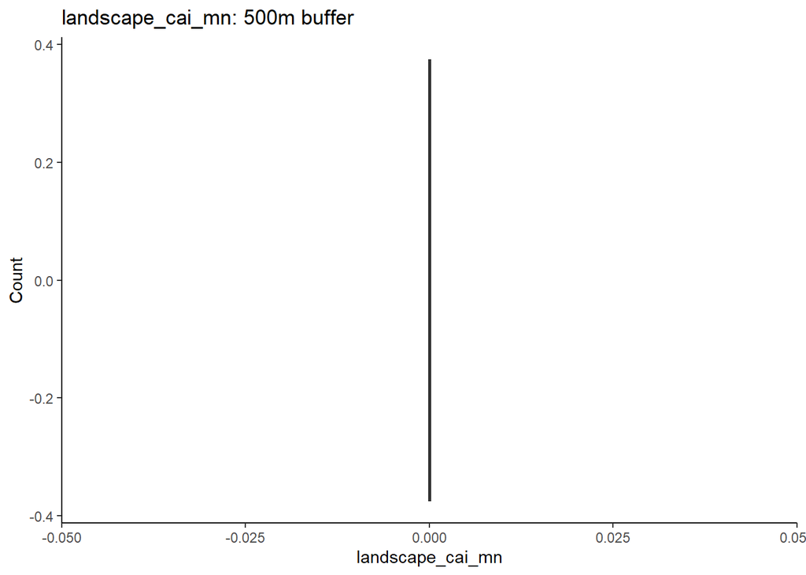

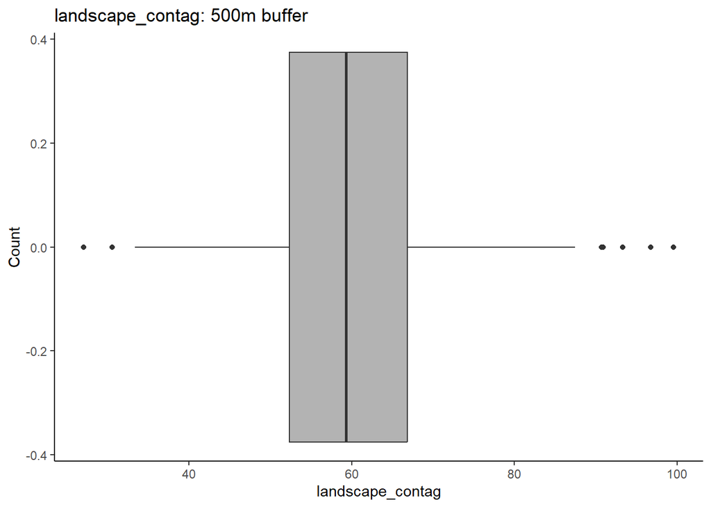

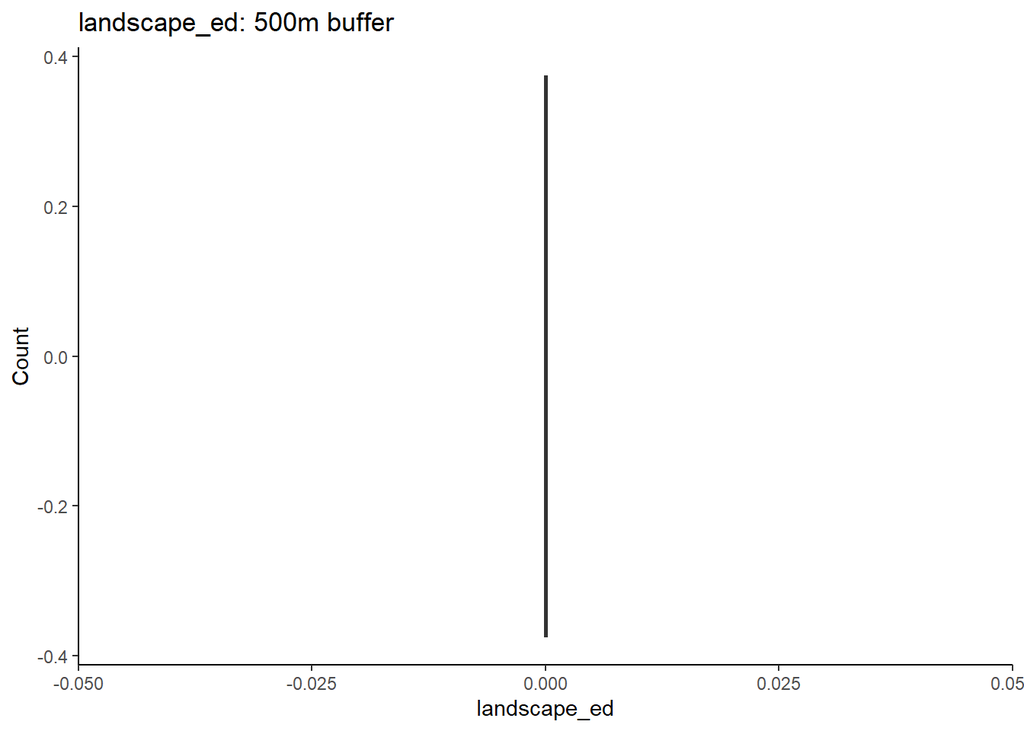

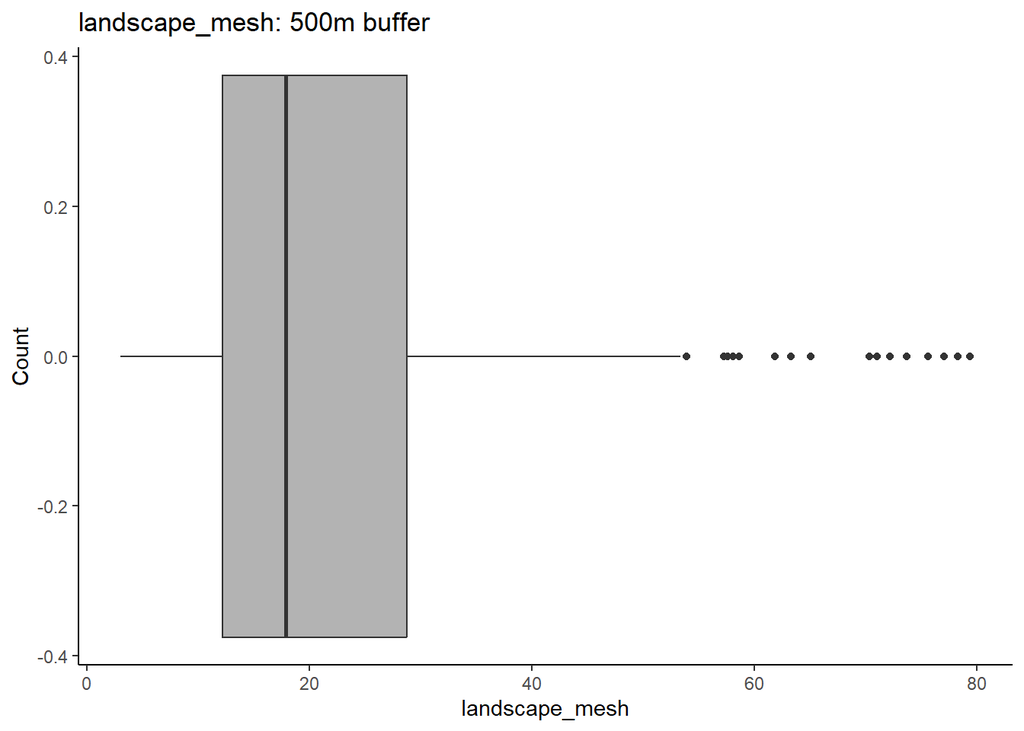

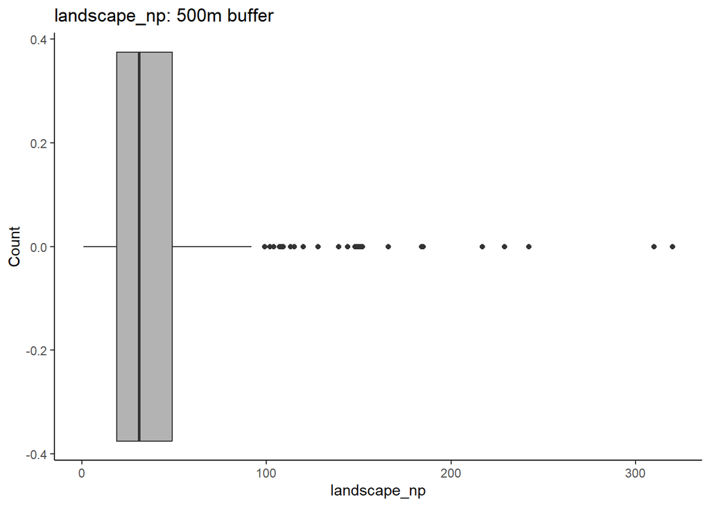

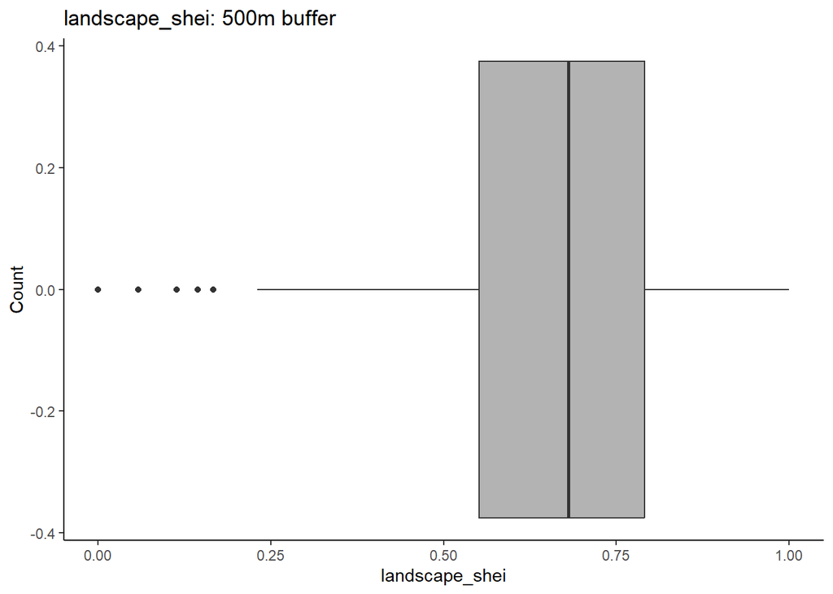

[24 more figures not shown]

```r
covs_to_explore %>%

  filter(buffer_dist == 500) %>%

  select(-(1:8)) %>%

  # use imap which will retain both the data (x) and the variable names (y)
  imap(~ ggplot(mapping = aes(x = .x)) +
         geom_boxplot(fill = "grey70", color = "grey20") +
         labs(title = paste0(.y, ": 500m buffer"), x = .y, y = "Count") +
         theme_classic())
```